# Day 4 homework by Ding Yang Wang

## Q1 Fit a log-linear model to explain the number of deaths for the most recent date

First, I loaded the cases data.

```r
cases <- read_delim("https://raw.githubusercontent.com/CSSEGISandData/COVID-19/master/csse_covid_19_data/csse_covid_19_time_series/time_series_covid19_confirmed_global.csv", delim = ",")
```

This function is to arrange the cases data into the form that I want.

```r
cases<- cases %>%
  select(-c(1,3,4)) %>% ##delete the unless data
  ##the function between ## is to sum up the amount of case per day that group by the same country name
  group_by(`Country/Region`) %>%
  summarise_all(funs(sum)) %>%
  ##
  pivot_longer(names_to = "date", values_to = "cases",-1) %>%##to make a long column data into row data
  mutate(date = as.Date(date, format = "%m/%d/%y")) %>%
  arrange(date)%>%
  group_by(`Country/Region`) %>%
  mutate(new_cases = cases - lag(cases))
```

Because I used `lag` function, the first date of the data will be `NA`. Thus, I used the while function to corrext the first date.

```r
num <- 1

while(is.na(cases$new_cases[num])){
  cases$new_cases[num] <- cases$cases[num]
  num <- num+1
}
```

Then we do the same step with deaths data.

```r
deaths <- read_delim("https://raw.githubusercontent.com/CSSEGISandData/COVID-19/master/csse_covid_19_data/csse_covid_19_time_series/time_series_covid19_deaths_global.csv", delim = ",")

deaths<- deaths %>%
  select(-c(1,3,4)) %>%
  ##the function between ## is to sum up the amount of deaths per day that group by the same country name
  group_by(`Country/Region`) %>%
  summarise_all(funs(sum)) %>%
  ##
  pivot_longer(names_to = "date", values_to = "deaths",-1) %>%##to make a long column data into row data
  mutate(date = as.Date(date, format = "%m/%d/%y")) %>%
  arrange(date)%>%
  group_by(`Country/Region`)%>%
  mutate(new_deaths = deaths - lag(deaths))

num <- 1

while(is.na(deaths$new_deaths[num])){
  deaths$new_deaths[num] <- deaths$deaths[num]
  num <- num+1
}
```

There is to combine two data frames and rename the colnme name.

```r
cases_deaths <- inner_join(cases, deaths, by = c("Country/Region", "date"))

cases_deaths<- rename(cases_deaths, country = "Country/Region")
```

Because the question is to see the deaths and cases data from the most recent date. Here, I choose 7 days data.

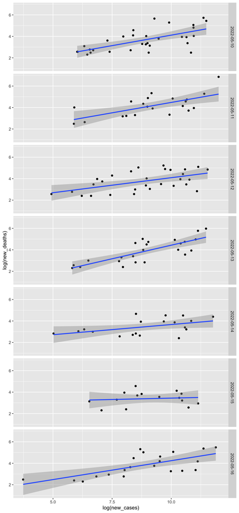

```r
recent_cases_deaths<- cases_deaths[(nrow(cases_deaths)-length(unique(cases_deaths$country))
*7+1):nrow(cases_deaths),]

recent_cases_deaths <- recent_cases_deaths%>%
  filter(new_cases >= 10 & new_deaths >= 10)

recent_cases_deaths %>% ggplot(aes(y = log(new_deaths), x = log(new_cases))) +
  geom_point() +
  stat_smooth(method = "lm") +
  theme(legend.position = "none")+
  facet_grid(date~.)
```

## Q2: Use the diagnostic plots to examine whether the model statistics are appropriate. Interpret the 4 diagnostic plots.

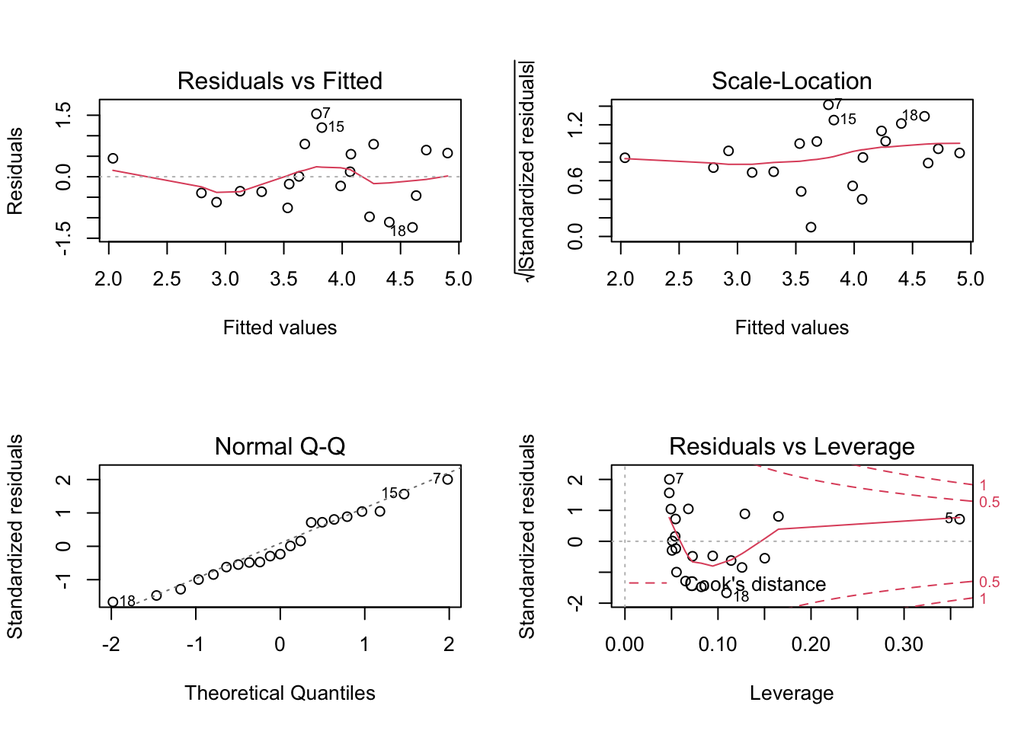

```r
last_date_cases_deaths <- cases_deaths[(nrow(cases_deaths)-length(unique(cases_deaths$country))+1):nrow(cases_deaths),]
last_date_cases_deaths <- last_date_cases_deaths%>%
  filter(new_cases >= 10 & new_deaths >= 10)

lm.last_date_cases_deaths <- lm( log(new_deaths)  ~ log(new_cases), last_date_cases_deaths)
layout(matrix(1:4,2,2)) #divide plotting window
plot(lm.last_date_cases_deaths)
```

The graphs are regression diagnostics.

**The Residual vs fitted graph**

The Residual vs fitted graph is used to check the linear relationship assumptions. There is distinct patterns in graph and the data is symmetrically distributed around a flat trend line. Those indicate a linear relationship is good.

More detail for Residual vs fitted graph:https://stats.stackexchange.com/questions/76226/interpreting-the-residuals-vs-fitted-values-plot-for-verifying-the-assumptions

**The Scale-Location graph**

More detail for Scale-Location graph: https://www.statology.org/scale-location-plot/

**The Normal Q-Q plot**

The Normal Q-Q plot shows the residuals follow a normal distribution.

More detail for qqplot: https://www.ucd.ie/ecomodel/Resources/QQplots_WebVersion.html

**The Residuals vs Leverage graph**

The Residuals vs Leverage graph is a type of diagnostic plot that allows us to identify influential observations in a regression model. Observations with high leverage have a strong influence on the coefficients in the regression model. If we remove these observations, the coefficients of the model would change noticeably.Standardized residuals refer to the standardized difference between a predicted value for an observation and the actual value of the observation.

There isn’t any observation fall outside of the dashed line. This means there are not any influential points in our regression model.

More detail for Residuals vs Leverage graph: https://www.statology.org/residuals-vs-leverage-plot/

**Answer**: According to those diagnostics graphs, the model statistics are appropriate!

## Q3: How much of the variance in the number of deaths is explained by the number of cases?

The R squared can get from the code below.

```r
last_date_cases_deaths <- cases_deaths[(nrow(cases_deaths)-length(unique(cases_deaths$country))+1):nrow(cases_deaths),]
last_date_cases_deaths <- last_date_cases_deaths%>%
  filter(new_cases >= 10 & new_deaths >= 10)

last_date_Diagnostics <- last_date_cases_deaths%>%
  select(country, new_deaths,new_cases)%>%
  nest() %>%
  mutate(linear_mod = map(data,  ~ tidy(lm(log(new_deaths) ~ log(new_cases),data=.)))) %>%
  unnest(linear_mod)

mod <- lm(log(new_deaths) ~ log(new_cases), last_date_cases_deaths) # get the least squares fit

b <- mod$coef

last_date_cases_deaths$CDest <- b[1] + b[2]*log(last_date_cases_deaths$new_cases)
m <- mean(log(last_date_cases_deaths$new_deaths))
SSM <- sum((m - last_date_cases_deaths$CDest)^2)
SST <- sum((m - log(last_date_cases_deaths$new_deaths))^2)
Rsquared <- SSM/SST
kable(Rsquared, caption = "Table 1: R Rsquared")
```

[output not shown]

## Q4: Identify the 10 countries for which our model gives the worst fit, using the residuals.

```r
last_date_cases_deaths$SR <- (log(last_date_cases_deaths$new_deaths) - last_date_cases_deaths$CDest)^2

SSE <- sum(last_date_cases_deaths$SR)

ten_countries <- last_date_cases_deaths[order(last_date_cases_deaths$SR, decreasing = TRUE),]

ten_countries <- ten_countries[c(1:10),-c(2:7)]
kable(ten_countries, caption = "Table 2: 10 countries for which our model gives the worst fit")
```

Table 2: 10 countries for which our model gives the worst fit

| country | SR |
| --- | --- |
| France | 2.3527005 |
| Taiwan* | 1.5260565 |
| Mexico | 1.4355727 |
| Korea, South | 1.2274105 |
| Japan | 0.9529713 |
| Russia | 0.6359310 |
| United Kingdom | 0.6290121 |
| South Africa | 0.5775951 |
| Germany | 0.4227262 |
| Czechia | 0.3854344 |

## Q5: Make a scatter-plot of deaths vs. cases, that shows the fit. Also label the outliers that you identified in the plot. BONUS: Color the outlier countries according to whether they have a higher or lower than average CFR.

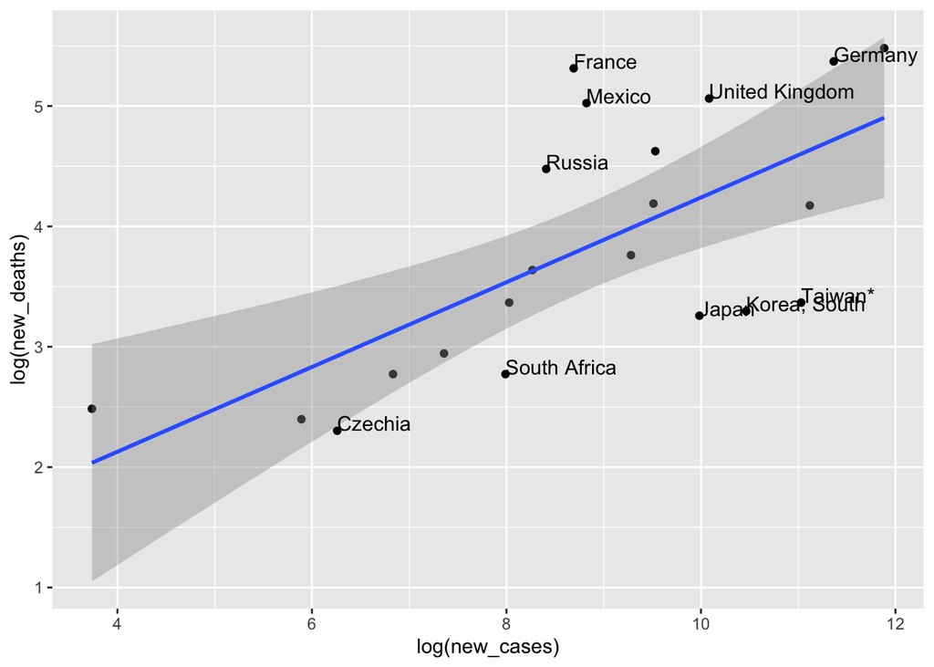

```r
last_date_cases_deaths %>% ggplot(aes(y = log(new_deaths),label= country, x = log(new_cases))) +
  geom_point() +
  stat_smooth(method = "lm") +
  geom_text(aes(label=ifelse(SR >= ten_countries$SR[10] ,as.character(country),'')),hjust=0,vjust=0)
```

# Packages & R verion